# Sprawozdanie 1

Adrian Pilarczyk, Maria Bul

Matematyka Stosowana

## Zadanie 1.

Treść:

Zaimportuj zbiór danych Carseats z biblioteki ISLR i dopasuj model (lub modele) regresji liniowej prostej przewidujący wartość zmiennej Sales. Zmienną objaśniającą dobierz według znanych metod (współczynnik korelacji, wykresy). Oceń jakość modelu ($R^2$, błąd standardowy) i zweryfikuj założenia (analiza reszt).

```r
library(tidyverse)
library(ISLR)
library(lmtest)
```

Rozwiązanie:

Zaczynamy od wczytania naszych danych do programu:

```r
carseats <- tibble::as.tibble(ISLR::Carseats)
head(carseats)
```

| Sales | CompPrice | Income | Advertising | Population | Price | ShelveLoc | Age | Education | Urban | US |
| --- | --- | --- | --- | --- | --- | --- | --- | --- | --- | --- |
| 9.50 | 138 | 73 | 11 | 276 | 120 | Bad | 42 | 17 | Yes | Yes |
| 11.22 | 111 | 48 | 16 | 260 | 83 | Good | 65 | 10 | Yes | Yes |
| 10.06 | 113 | 35 | 10 | 269 | 80 | Medium | 59 | 12 | Yes | Yes |
| 7.40 | 117 | 100 | 4 | 466 | 97 | Medium | 55 | 14 | Yes | Yes |
| 4.15 | 141 | 64 | 3 | 340 | 128 | Bad | 38 | 13 | Yes | No |
| 10.81 | 124 | 113 | 13 | 501 | 72 | Bad | 78 | 16 | No | Yes |

Następnie postaramy się dopasować model (lub modele), które bedą przewidywały w sposób liniowy wartość zmiennej $Sales$. Aby to zrobić, potrzebujemy znaleźć zmienną objaśniającą do $Sales$, która najbardziej odpowiada do modelu regresji liniowej. Najpierw zapoznajmy się z naszymi danymi:

```r
summary(carseats)
```

```
##      Sales          CompPrice       Income        Advertising
##  Min.   : 0.000   Min.   : 77   Min.   : 21.00   Min.   : 0.000
##  1st Qu.: 5.390   1st Qu.:115   1st Qu.: 42.75   1st Qu.: 0.000
##  Median : 7.490   Median :125   Median : 69.00   Median : 5.000
##  Mean   : 7.496   Mean   :125   Mean   : 68.66   Mean   : 6.635
##  3rd Qu.: 9.320   3rd Qu.:135   3rd Qu.: 91.00   3rd Qu.:12.000
##  Max.   :16.270   Max.   :175   Max.   :120.00   Max.   :29.000
##    Population        Price        ShelveLoc        Age          Education
##  Min.   : 10.0   Min.   : 24.0   Bad   : 96   Min.   :25.00   Min.   :10.0
##  1st Qu.:139.0   1st Qu.:100.0   Good  : 85   1st Qu.:39.75   1st Qu.:12.0
##  Median :272.0   Median :117.0   Medium:219   Median :54.50   Median :14.0
##  Mean   :264.8   Mean   :115.8                Mean   :53.32   Mean   :13.9
##  3rd Qu.:398.5   3rd Qu.:131.0                3rd Qu.:66.00   3rd Qu.:16.0
##  Max.   :509.0   Max.   :191.0                Max.   :80.00   Max.   :18.0
##  Urban       US
##  No :118   No :142
##  Yes:282   Yes:258
##
##
##
##
```

W analizowanym zestawie danych występują nie tylko zmienne ilościowe, lecz również zmienne jakościowe. W naszym przypadku zmienne jakościowe obejmują: $ShelveLoc$, $Urban$ oraz $US$, ale mogą mieć związek liniowy z naszą zmienną objaśnianą. Powinniśmy je zamienić na wartości liczbowe. Sprawdźmy na początek, czy wśród obserwacji mogą występować brakujące dane:

```r
anyNA(carseats)
```

```
## [1] FALSE
```

Zatem stworzymy nowy zbiór danych z samymi wartościami liczbowymi, zamieniając nasze zmienne jakościowe:

```r
carseats_numer <- carseats
carseats_numer$ShelveLoc <- as.numeric(factor(Carseats$ShelveLoc))
carseats_numer$Urban <- as.numeric(factor(Carseats$Urban))
carseats_numer$US <- as.numeric(factor(Carseats$US))
carseats_numer
```

| Sales | CompPrice | Income | Advertising | Population | Price | ShelveLoc | Age | Education | Urban | US |
| --- | --- | --- | --- | --- | --- | --- | --- | --- | --- | --- |
| 9.50 | 138 | 73 | 11 | 276 | 120 | 1 | 42 | 17 | 2 | 2 |
| 11.22 | 111 | 48 | 16 | 260 | 83 | 2 | 65 | 10 | 2 | 2 |
| 10.06 | 113 | 35 | 10 | 269 | 80 | 3 | 59 | 12 | 2 | 2 |
| 7.40 | 117 | 100 | 4 | 466 | 97 | 3 | 55 | 14 | 2 | 2 |
| 4.15 | 141 | 64 | 3 | 340 | 128 | 1 | 38 | 13 | 2 | 1 |
| 10.81 | 124 | 113 | 13 | 501 | 72 | 1 | 78 | 16 | 1 | 2 |
| 6.63 | 115 | 105 | 0 | 45 | 108 | 3 | 71 | 15 | 2 | 1 |
| 11.85 | 136 | 81 | 15 | 425 | 120 | 2 | 67 | 10 | 2 | 2 |
| 6.54 | 132 | 110 | 0 | 108 | 124 | 3 | 76 | 10 | 1 | 1 |
| 4.69 | 132 | 113 | 0 | 131 | 124 | 3 | 76 | 17 | 1 | 2 |

[output cut: 390 more lines]

Możemy przystąpić do wyznaczania zmiennej objaśniającej do naszych modeli. Obliczymy współczynniki korelacji Pearsona $Sales$ z każdą poszczególną zmienną w naszej bazie danych oraz stworzymy wykresy pokazujące każdą zmienną do zmiennej $Sales$ (analiza wykresów i korelacji):

```r
correlation_sales <- cor(carseats_numer$Sales, carseats_numer)
print(correlation_sales)
```

```
##      Sales  CompPrice   Income Advertising Population      Price ShelveLoc
## [1,]     1 0.06407873 0.151951   0.2695068 0.05047098 -0.4449507 0.1574697
##             Age   Education       Urban        US
## [1,] -0.2318154 -0.05195524 -0.01541944 0.1770933
```

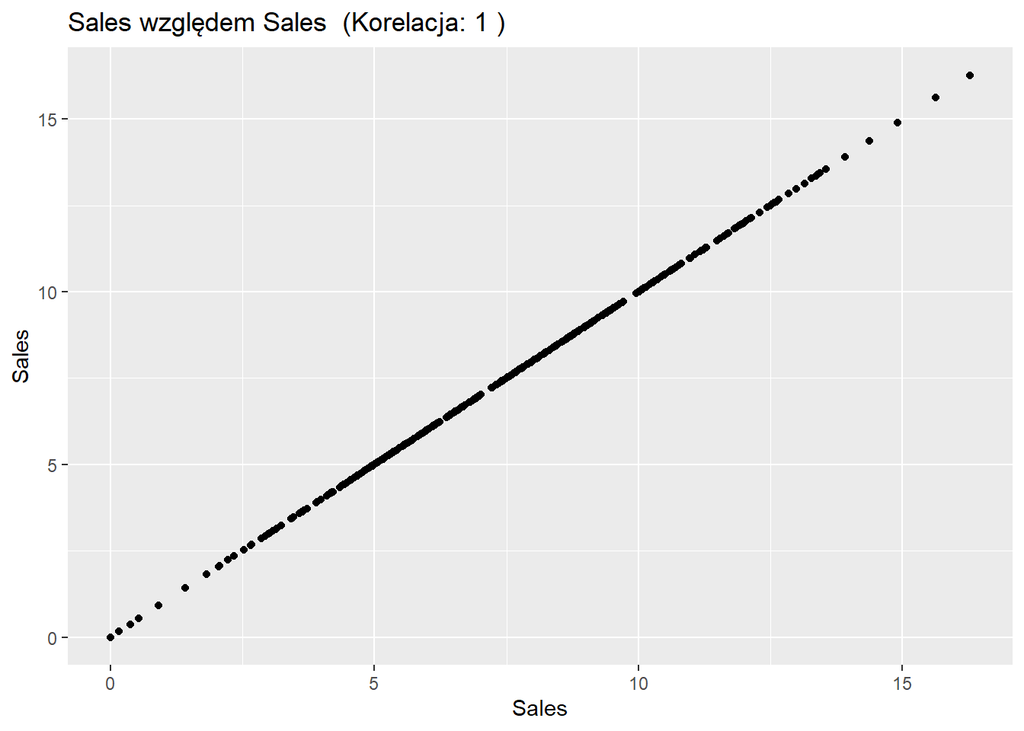

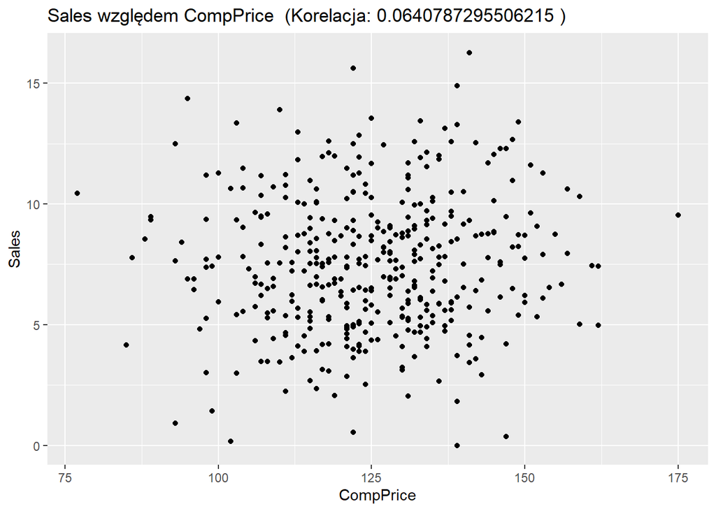

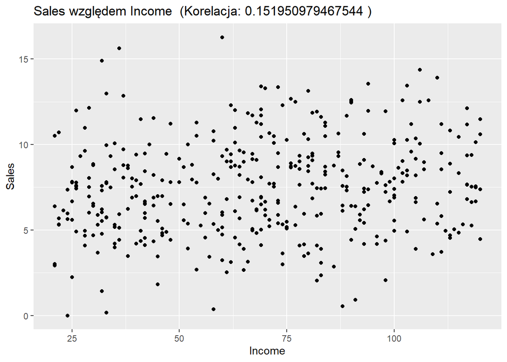

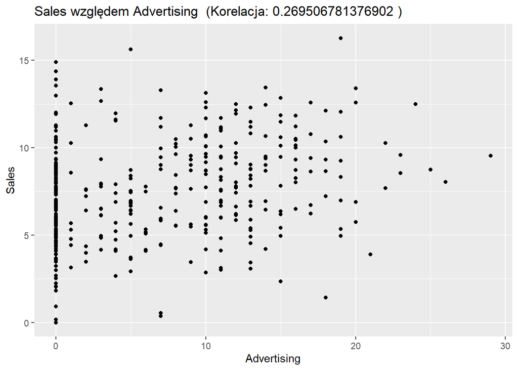

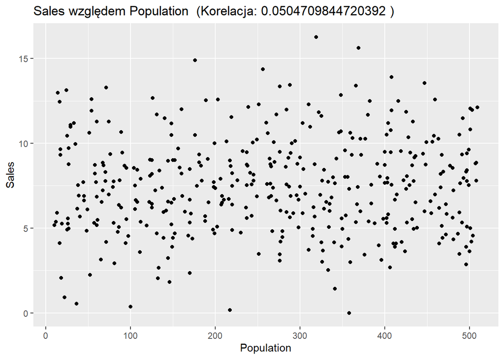

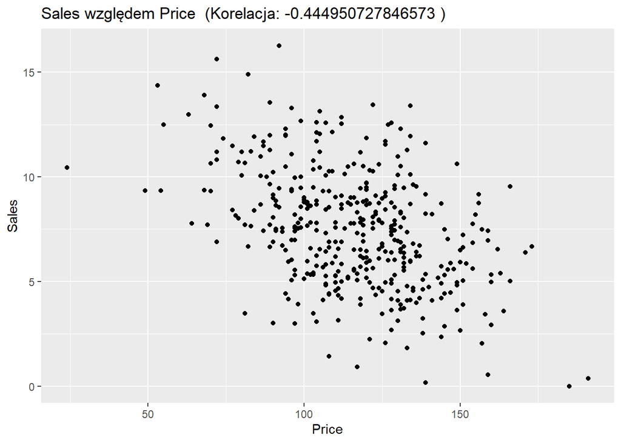

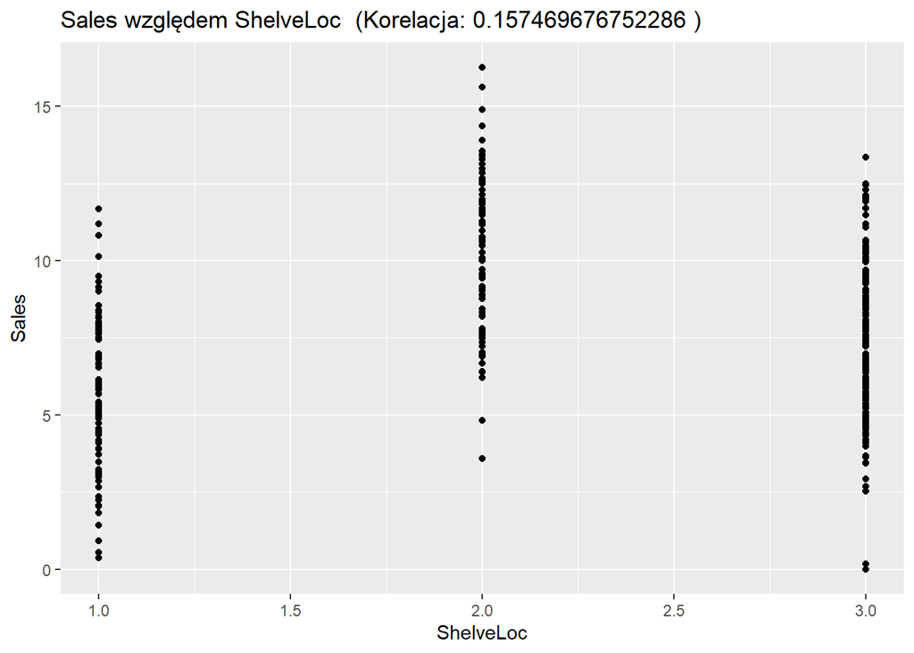

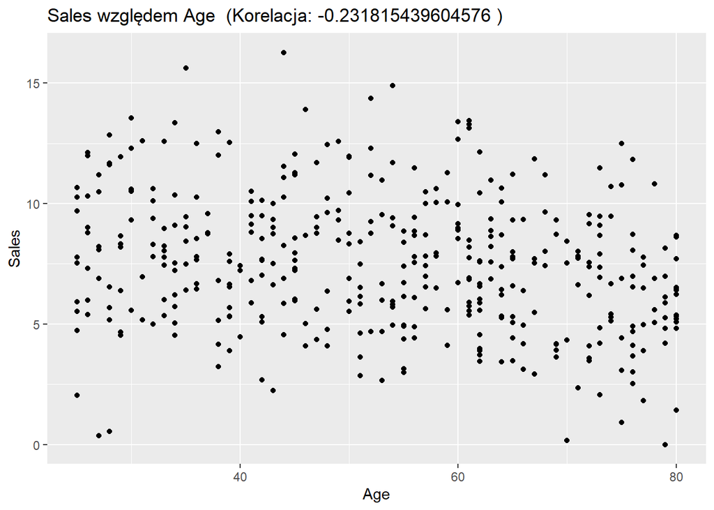

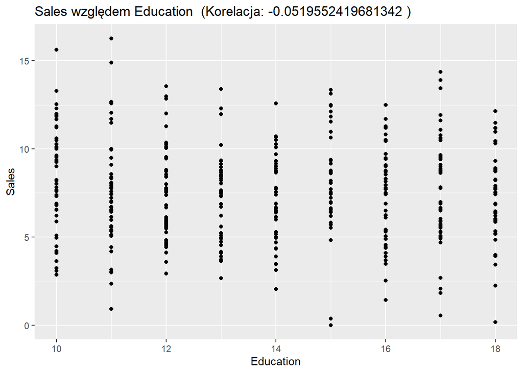

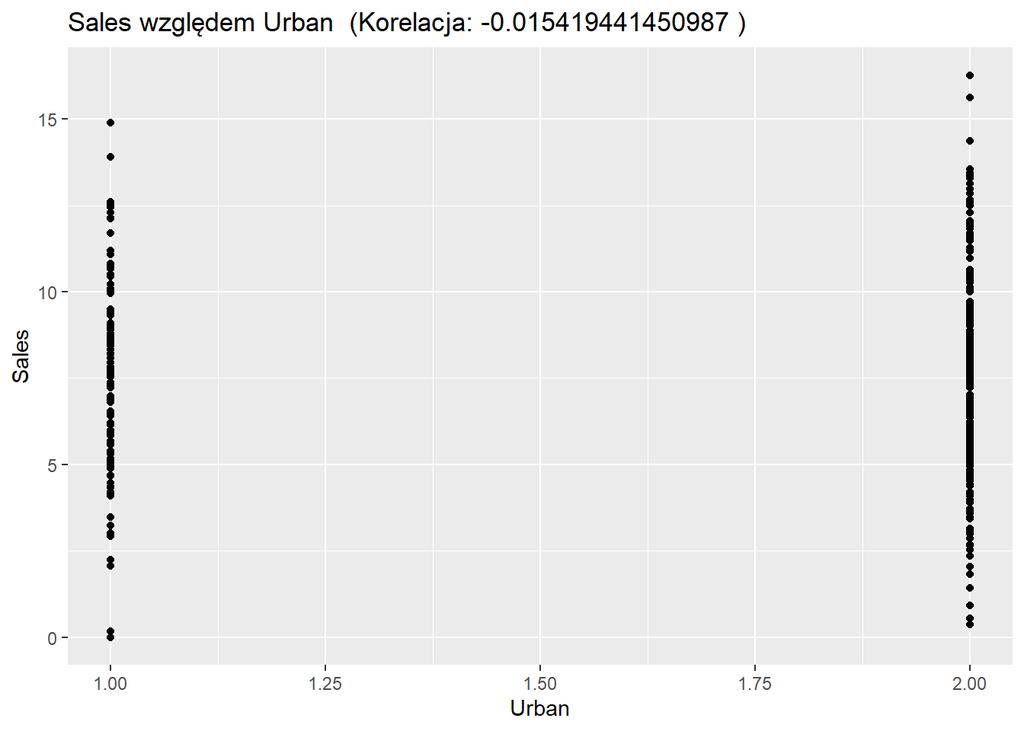

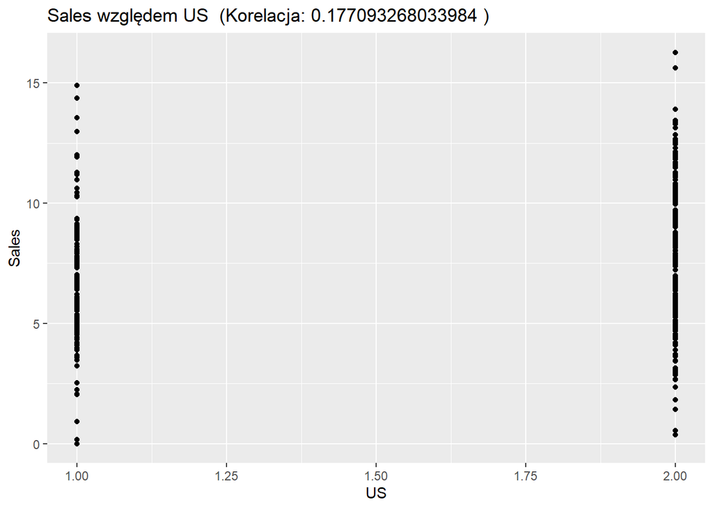

```r
for (col_name in names(carseats_numer)) {
  p <- ggplot(data = carseats_numer, aes_string(x = col_name, y = "Sales")) +
    geom_point() + labs(x = col_name, y = "Sales") + ggtitle(paste("Sales względem", col_name," (Korelacja:", cor(carseats_numer$Sales, carseats_numer[[col_name]]), ")"))
  print(p)
}
```

Stwórzmy macierz korelacji, aby wyraźniej zobaczyć, które korelacje są najsilniejsze dla naszej zmiennej:

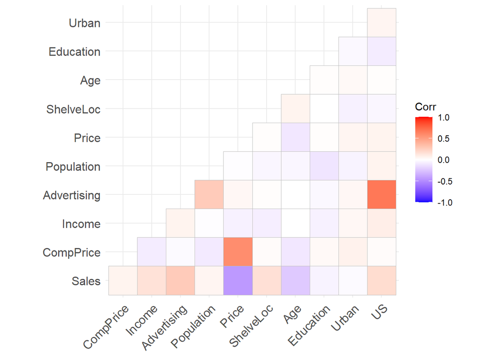

```r
library(ggcorrplot)
ggcorrplot(cor(carseats_numer), type='lower')
```

Zauważamy, że największe współczynniki korelacji na moduł są dla zmiennych $Price$, $Advertising$ oraz $Age$. Pomimo tego, że $r_{xy}<0,5$ jest to dalej korelacja przeciętna, zatem te zmienne mają związek z $Sales$. Pozostałe zmienne mają korelacje $r_{xy}<0,2$, więc są dużo mniej istotne od pozostałych (korelacja nikła) lub też bliskie zeru (zmienne nie są skorelowane). Mogą mało wpływać na naszą zmienną objaśnianą.

Klasyczny model regresji liniowej prostej wygląda następująco
$$y_i = \beta_0 + \beta_1 x_i +
\varepsilon_i$$
dla zmiennej objaśnianej $y$, zmiennej objaśniającej $x$ i szumu $\varepsilon_i \stackrel{iid}{\sim} N(0,\sigma^2)$. Staramy się, aby reszta modelu $\varepsilon_i$ była jak najmniejsza, aby jak najlepiej dopasować model.

Stwórzmy teraz pierwszy model regresji liniowej przewidujący wartość zmiennej $Sales$ na podstawie $Price$, która miała największy na moduł współczynnik korelacji (wartość), zatem wpływa najlepiej z wszystkich innych na naszą zmienną objaśnianą. Z wykresu oraz macierzy korelacji jasno wynika, że optymalnym wyborem jako zmiennej objaśniającej dla wpływu na zmienną $Sales$ jest zmienna $Price$. Obserwujemy wyraźną, ujemną korelację między ceną, a poziomem sprzedaży, co sugeruje, że niższe ceny są związane z wyższymi wartościami sprzedaży.

Model:

```r
sales_price_model <- lm(carseats_numer$Sales~carseats_numer$Price, data=carseats_numer)
sales_price_summary <- summary(sales_price_model)
sales_price_summary
```

```
##
## Call:
## lm(formula = carseats_numer$Sales ~ carseats_numer$Price, data = carseats_numer)
##
## Residuals:
##     Min      1Q  Median      3Q     Max
## -6.5224 -1.8442 -0.1459  1.6503  7.5108
##
## Coefficients:
##                       Estimate Std. Error t value Pr(>|t|)
## (Intercept)          13.641915   0.632812  21.558   <2e-16 ***
## carseats_numer$Price -0.053073   0.005354  -9.912   <2e-16 ***
## ---
## Signif. codes:  0 '***' 0.001 '**' 0.01 '*' 0.05 '.' 0.1 ' ' 1
##
## Residual standard error: 2.532 on 398 degrees of freedom
## Multiple R-squared:  0.198,  Adjusted R-squared:  0.196
## F-statistic: 98.25 on 1 and 398 DF,  p-value: < 2.2e-16
```

Przeprowadźmy teraz analize naszego modelu.

Możemy zauważyć, że reszty w naszy modelu wachają się między $-6.5224$ a $7.5108$. Jest to duży rozrzut reszt, natomiast większość skupia się w okolicach 1Q i 3Q, gdzie również mediana jest bardzo bliska $0$. Średni błąd resztowy wynosi $2.532$, co oznacza, że średnia różnica między rzeczywistymi a przewidywanymi wartościami sprzedaży wynosi $2.532$ jednostki.

Wartość współczynnika Intercept wynosi $13.641915$. Oznacza to, że gdy cena wynosi $0$, przewidywana wartość sprzedaży wynosi $13.64$ jednostki. Natomiast wartość współczynnika $Price$ wynosi $-0.053073$, co oznacza, że jeżeli cena wzrośnie o jednostkę, przewidywana wartość sprzedaży spada o $0.053073$ jednostki (dlatego, że współczynnik korelacji był ujemny i wzrasta odwrotnie proporcjonalnie). Dla każdego współczynnika dopasowanie jest na poziomie $3*$.

Błędy standardowe oszacowań współczynników wynoszą $0.632812$ dla punktu przecięcia i $0.005354$ dla współczynnika $Price$. Im niższa wartość błędu standardowego, tym oszacowanie jest bardziej precyzyjne. Wartości t (t-value) dla punktu przecięcia i $Price$ potwierdzają istotność statystyczną obu współczynników, co wskazuje na ich istotny wpływ na zmienną objaśnianą.

Wartość Multiple R-squared $R^2$ wynosi $0.198$, co oznacza, że około $19.8%$ zmienności sprzedaży jest wyjaśniane przez zmienną $Price$. Jednak wartość ta sugeruje, że cena samodzielnie wyjaśnia tylko niewielką część zmienności w sprzedaży. Jest na bardzo niskim poziomie.

Podsumowując, istnieje istotna zależność liniowa między zmienną $Sales$ a $Price$. Tak się prezentuje wykres naszych danych wraz z wyestymowaną linią regresji:

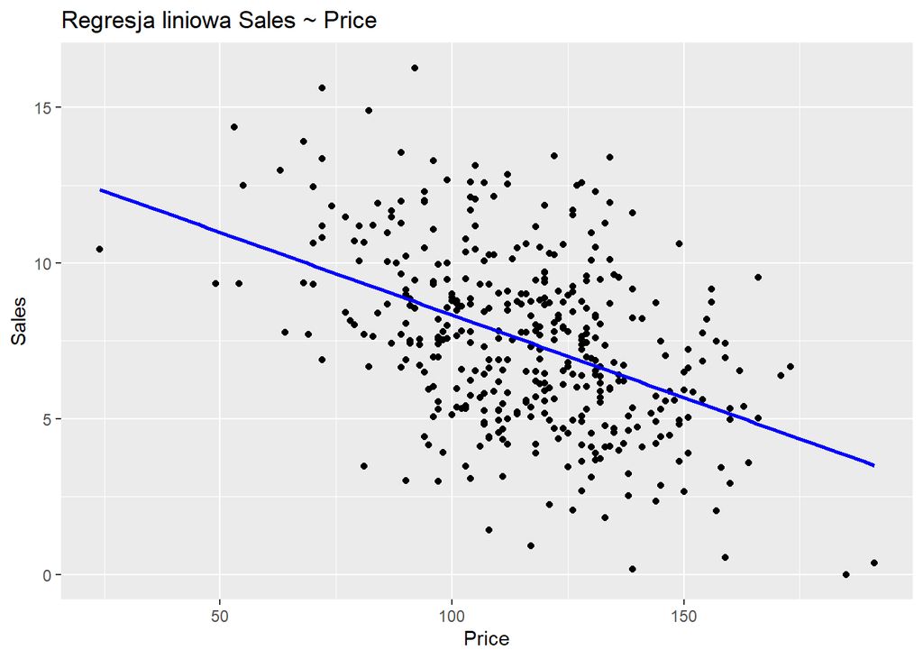

```r
ggplot(data = carseats_numer, aes(x = Price, y = Sales)) + geom_point() +  geom_smooth(method = "lm", se = FALSE, color = "blue") +
  labs(title = "Regresja liniowa Sales ~ Price", x = "Price", y = "Sales")
```

Zanim przejdziemy do założen modelu, spróbujemy ulepszyć nasz model ze względu na niski współczynnik $R^2$ oraz odstające reszty.

W tym celu stworzymy histogramy modelu, aby zobaczyć rozkład zmiennych:

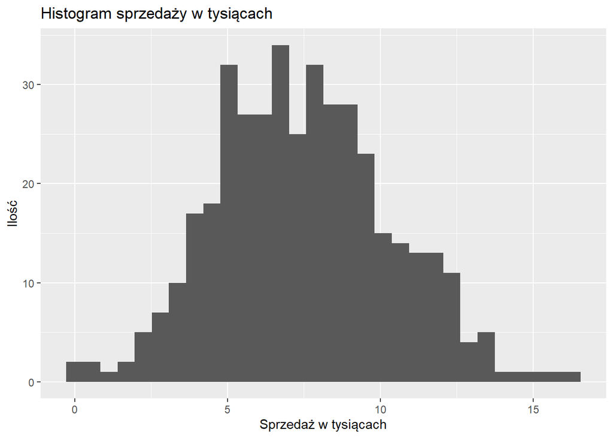

```r
ggplot(carseats_numer, aes(x=Sales)) + geom_histogram(bins = 30) + ggtitle('Histogram sprzedaży w tysiącach') + xlab("Sprzedaż w tysiącach") + ylab("Ilość")
```

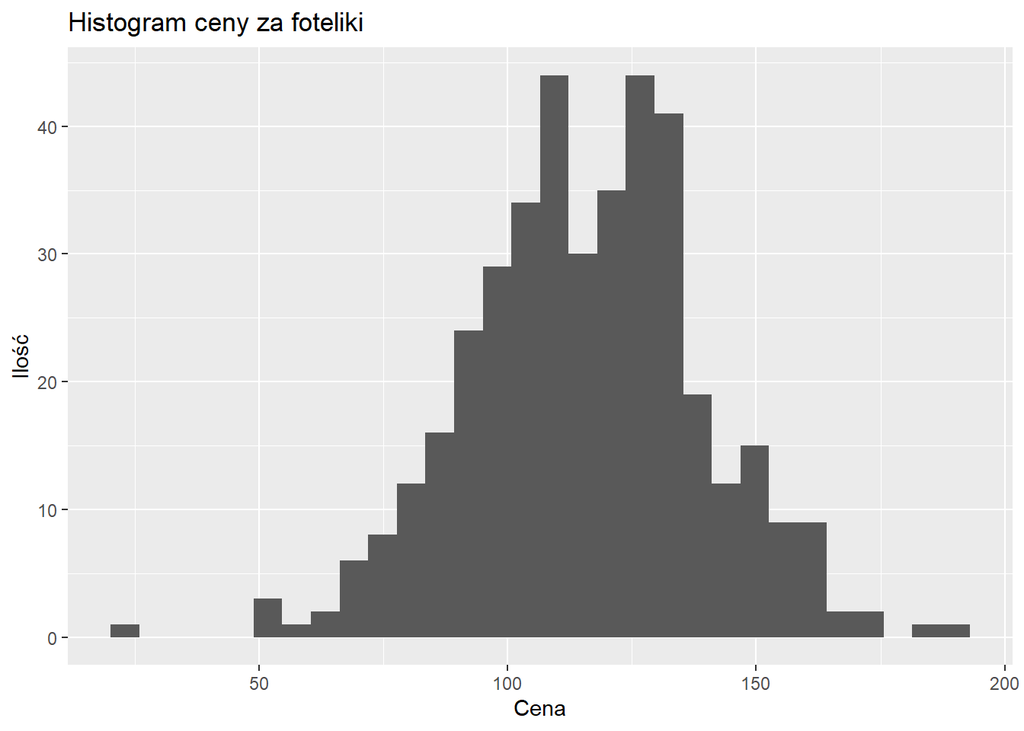

```r
ggplot(carseats_numer, aes(x=Price)) + geom_histogram(bins = 30) + ggtitle('Histogram ceny za foteliki') + xlab("Cena") + ylab("Ilość")
```

W naszej zmiennej objaśnianej $Sales$ nie zauważamy wartości odstających. Można zauważyć od razu z histogramu dla $Price$, że istnieją wartości odstające. W celu poprawienia jakości modelu pozbędziemy się ich. Zbadajmy kwartyle naszej ceny, aby odrzucić skrajne obserwacje:

```r
quantile(carseats_numer$Price)
```

```
##   0%  25%  50%  75% 100%
##   24  100  117  131  191
```

```r
c(quantile(carseats_numer$Price, 0.05), quantile(carseats_numer$Price, 0.10), quantile(carseats_numer$Price, 0.90), quantile(carseats_numer$Price, 0.95))
```

```
##     5%    10%    90%    95%
##  77.00  87.00 146.00 155.05
```

Zauważamy, że faktycznie jest przeskok między danymi na podstawie kwartyli. Przez to, że są to pojedyńcze obserwacje odstające na końcach, nie powinny wpłynąć znacząco na model przez symetryczny i nie znacząco skośny histogram. Spróbujmy zatem wyeliminować te obserwacje. Zróbmy wykres pokazujący, gdzie występują za pomocą boxplotu:

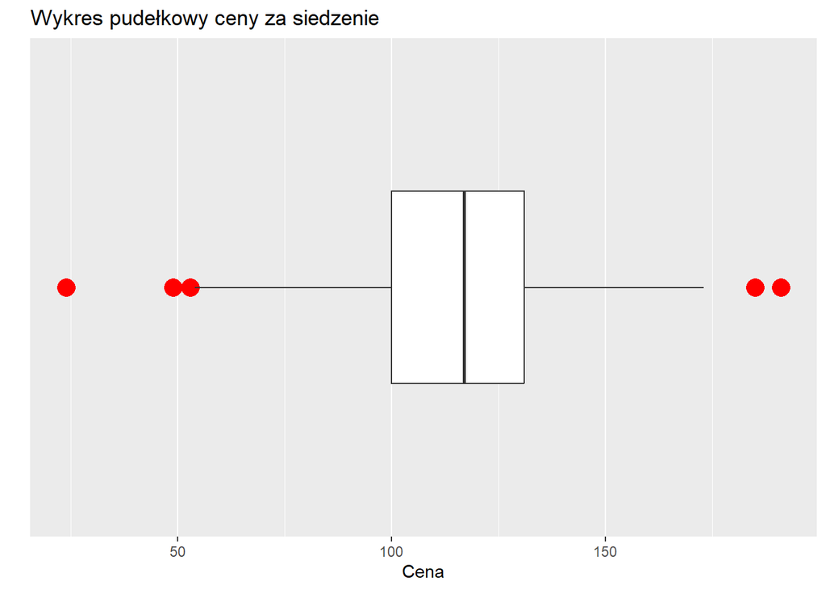

```r
ggplot(carseats_numer, aes(x=Price)) + geom_boxplot(outlier.color='red', outlier.size=5) +
  labs(title="Wykres pudełkowy ceny za siedzenie", x='Cena', y = "") + scale_y_discrete(labels=NULL, breaks=NULL)
```

```r
rightmost_value <- quantile(carseats_numer$Price, 0.75)+1.5*IQR(carseats_numer$Price)
dplyr::filter(carseats_numer, Price > rightmost_value)
```

| Sales | CompPrice | Income | Advertising | Population | Price | ShelveLoc | Age | Education | Urban | US |
| --- | --- | --- | --- | --- | --- | --- | --- | --- | --- | --- |
| 0.37 | 147 | 58 | 7 | 100 | 191 | 1 | 27 | 15 | 2 | 2 |
| 0.00 | 139 | 24 | 0 | 358 | 185 | 3 | 79 | 15 | 1 | 1 |

```r
leftmost_value <- quantile(carseats_numer$Price, 0.25)- 1.5*IQR(carseats_numer$Price)
dplyr::filter(carseats_numer, Price < leftmost_value)
```

| Sales | CompPrice | Income | Advertising | Population | Price | ShelveLoc | Age | Education | Urban | US |
| --- | --- | --- | --- | --- | --- | --- | --- | --- | --- | --- |
| 10.43 | 77 | 69 | 0 | 25 | 24 | 3 | 50 | 18 | 2 | 1 |
| 9.34 | 89 | 78 | 0 | 181 | 49 | 3 | 43 | 15 | 1 | 1 |
| 14.37 | 95 | 106 | 0 | 256 | 53 | 2 | 52 | 17 | 2 | 1 |

```r
carseats_numer_filtr2 <- carseats_numer %>% dplyr::mutate(Price = ifelse(Price > rightmost_value, rightmost_value, Price))
carseats_numer_filtr2 <- carseats_numer %>% dplyr::mutate(Price = ifelse(Price < leftmost_value, leftmost_value, Price))
```

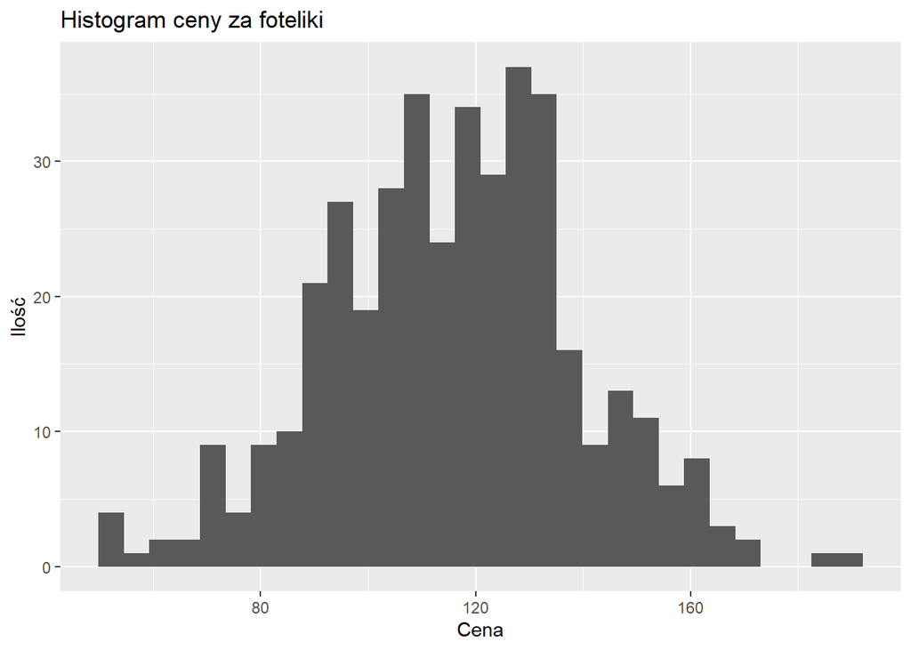

```r
ggplot(carseats_numer_filtr2, aes(x=Price)) + geom_histogram(bins = 30) + ggtitle('Histogram ceny za foteliki') + xlab("Cena") + ylab("Ilość")
```

Spróbujemy stworzyć ponownie model:

```r
sales_price_model2 <- lm(carseats_numer_filtr2$Sales~carseats_numer_filtr2$Price, data=carseats_numer_filtr2)
sales_price_summary2 <- summary(sales_price_model2)
sales_price_summary2
```

```
##
## Call:
## lm(formula = carseats_numer_filtr2$Sales ~ carseats_numer_filtr2$Price,
##     data = carseats_numer_filtr2)
##
## Residuals:
##     Min      1Q  Median      3Q     Max
## -6.5260 -1.7971 -0.1425  1.6565  7.4868
##
## Coefficients:
##                              Estimate Std. Error t value Pr(>|t|)
## (Intercept)                 13.740523   0.639903  21.473   <2e-16 ***
## carseats_numer_filtr2$Price -0.053884   0.005413  -9.955   <2e-16 ***
## ---
## Signif. codes:  0 '***' 0.001 '**' 0.01 '*' 0.05 '.' 0.1 ' ' 1
##
## Residual standard error: 2.53 on 398 degrees of freedom
## Multiple R-squared:  0.1993, Adjusted R-squared:  0.1973
## F-statistic: 99.09 on 1 and 398 DF,  p-value: < 2.2e-16
```

Zauważamy, że wszystkie parametry i współczynniki są bardzo zbliżone do poprzednich. Współczynnik $R^2$ podniósł się o nieznączą wartość do góry. Model wydaje się być dobry pomimo niskiego współczynnika $R^2$ oraz odstających reszt.

Przejdźmy zatem do założeń modelu regresji liniowej:

### Założenie 1: Zależność liniowa

W celu sprawdzenia założenia o zależności liniowej, skorzystamy z wykresu punktowego oraz współczynnika korelacji Pearsona.

Zacznijmy od sprawdzenia współczynnika korelacji Pearsona dla naszych dwóch zmiennych w modelu:

```r
cor.test(carseats_numer$Sales, carseats_numer$Price)
```

```
##
##  Pearson's product-moment correlation
##
## data:  carseats_numer$Sales and carseats_numer$Price
## t = -9.912, df = 398, p-value < 2.2e-16
## alternative hypothesis: true correlation is not equal to 0
## 95 percent confidence interval:
##  -0.5203026 -0.3627240
## sample estimates:
##        cor
## -0.4449507
```

Niska wartość p-value mówi, że możemy odrzucić hipotezę zerową, co oznacza, że rzeczywista korelacja nie jest równa zeru, tak jak wyszło nam wcześniej. Analiza testu korelacji Pearsona wskazuje, że istnieje ujemna korelacja $-0.4449507$. Możemy stwierdzić, że wraz ze wzrostem ceny produktu sprzedaż maleje i na odwrót. Współczynnik korelacji jest istotny dla modelu.

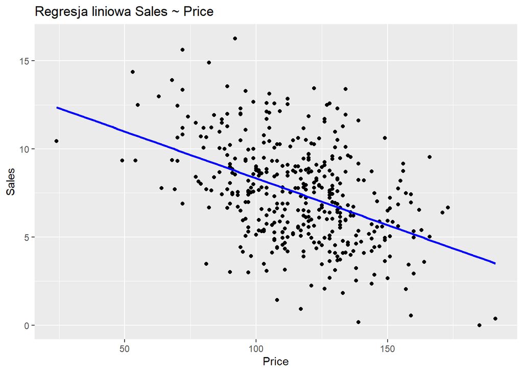

```r
ggplot(data = carseats_numer, aes(x = Price, y = Sales)) + geom_point() +  geom_smooth(method = "lm", se = FALSE, color = "blue") +
  labs(title = "Regresja liniowa Sales ~ Price", x = "Price", y = "Sales")
```

Spoglądając na ten wykres nie wykluczamy zależności liniowej. Wartości są skupione w pobliżu prostej. Możemy stwierdzić, że założenie jest spełnione i przechodzimy do następnego.

### Założenie 2.1: Rozkład reszt

Do zbadania normalności reszt możemy wykresu kwartyl-kwartyl oraz testu Shapiro-Wilka:

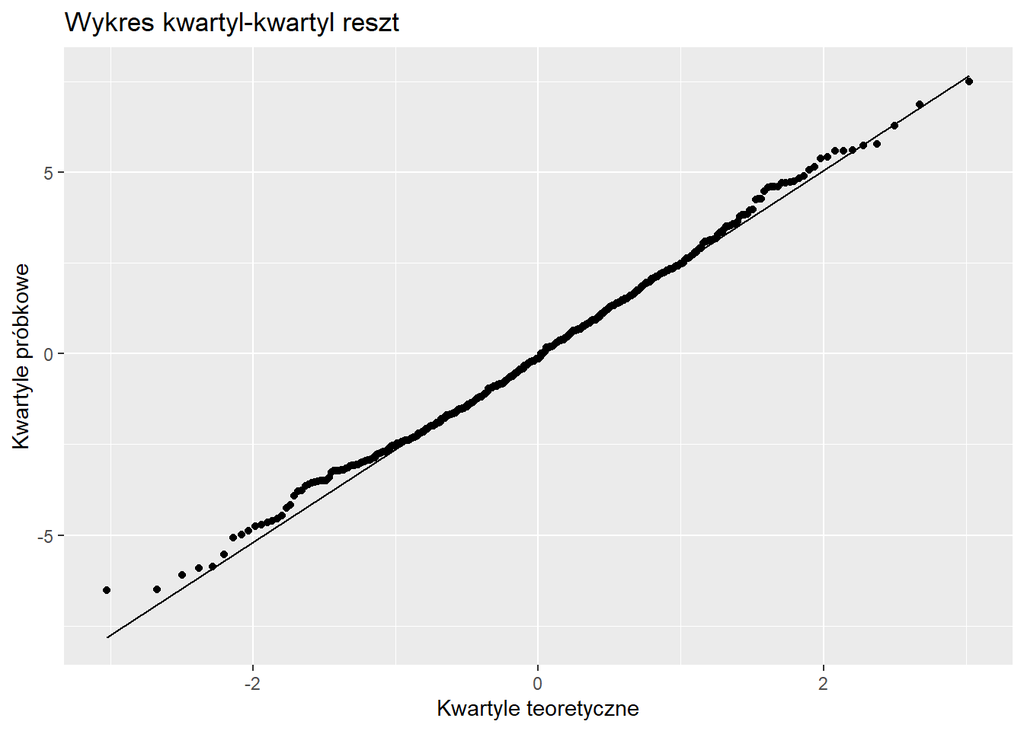

```r
ggplot(sales_price_model2, aes(sample=.resid)) + geom_qq() + geom_qq_line() + labs(title='Wykres kwartyl-kwartyl reszt', x='Kwartyle teoretyczne', y='Kwartyle próbkowe')
```

Większość punktów znajduje się blisko linii prostej, a pozostałe zdają się być zgodne z rozkładem normalnym. Niewielkie odstępstwa, zauważalne na początku i końcu wykresu, są akceptowalne.

Teraz zróbmy test Shapiro-Wilka, aby potwierdzić naszą tezę:

```r
shapiro.test(sales_price_model2$residuals)
```

```
##
##  Shapiro-Wilk normality test
##
## data:  sales_price_model2$residuals
## W = 0.99545, p-value = 0.2955
```

Test Shapiro-Wilka służy do oceny zgodności reszt modelu z rozkładem normalnym. Wynik $0.99545$ wskazuje na większą zgodność z rozkładem normalnym. Wartość p-value $0.2955$ przekracza poziom istotności $0.05$ oznacza, że nie ma podstaw do odrzucenia hipotezy zerowej. Zatem wynik ten wskazuje, że reszty modelu mają rozkład normalny.

Przejdźmy więc do weryfikacji dalszych założeń.

### Założenie 2.2: Zerowa średnia reszt

Skorzystajmy z klasycznego testu t-Studenta, aby sprawdzić średnią reszt:

```r
t.test(sales_price_model2$residuals)
```

```
##
##  One Sample t-test
##
## data:  sales_price_model2$residuals
## t = 9.5176e-16, df = 399, p-value = 1
## alternative hypothesis: true mean is not equal to 0
## 95 percent confidence interval:
##  -0.248395  0.248395
## sample estimates:
##    mean of x
## 1.202543e-16
```

Brak istotności statystycznej w tym teście sugeruje, że średnia reszt nie różni się istotnie od zera.